# Caso_practico_2

## Enunciado

Se dispone del siguiente archivo CSV (descárgalo al final del enunciado) con información sobre los Air Bnb de la ciudad de Milán en 2019. En el dataset, solamente aparecen apartamentos completos. El dataset original y la explicación de todas las columnas está disponible en el siguiente enlace:

https://www.kaggle.com/antoniokaggle/milan-airbnb-open-data-only-entire-apartments

Con esta información, alumno debe realizar los siguientes procesos de analítica:

- Cargar el archivo “Airbnb_Milan.csv” como dataframe.
- Crear un nuevo dataframe que contenga únicamente las siguientes columnas:
  - “host_is_superhost”
  - “host_identity_verified”
  - “bathrooms”
  - “bedrooms”
  - “daily_price”
  - “security_deposit”
  - “minimum_nights”
  - “number_of_reviews”
  - “review_scores_rating”
- Cambiar los factores de la variable “host_is_superhost” de 0, 1 a: “SI” y, “NO”. (investigar la función recode).
- Cambiar los factores de la variable “host_identity_verified” de 0, 1 a: “VERIFICA” y “NO VERIFICA”.
- Mostrar un resumen estadístico de los datos.
- Filtrar el dataset por apartamentos cuyo mínimo de noches sea igual o menor que siete.
- ¿Cuál es el precio medio por día de una habitación en función de si el anfitrión tiene verificado o no su perfil?
- Quién tiene más número de reseñas, ¿un super host o no super host?
- Sobre la estadística anterior ¿quién tiene la puntuación media más alta?
- Crea un vector categórico llamado “CATEGORÍA”, en función de que, si para la puntuación de las reseñas tiene de 0 a 49, sea “NO ACONSEJABLE”; de 50 a 75 sea “ESTÁNDAR”; y de 76 a 100 sea “TOP”.
- Mostrar las frecuencias de la variable CATEGORÍA.
- Obtener el histograma del precio por día.
- Estudiar la relación entre los dormitorios y baños de forma gráfica.
- Mostrar un histograma del número de reseñas en función de si es un usuario verificado o no.
- Mostrar un histograma por cada valor de “CATEGORÍA” en el que se enseñe la cuantía del depósito de seguridad en función de si el anfitrión es super host o no.

```r
#Cargar Librerías

library(tidyr)
library(dplyr)
```

```r
library(ggplot2)
```

```r
# Carga de Archivo CSV

df_1 <- read.csv("Airbnb_Milan.csv", header = TRUE)
```

```r
head(df_1)
```

|  | X | id | host_id | host_location | host_response_time | host_response_rate | host_is_superhost | host_total_listings_count | host_has_profile_pic | host_identity_verified | neighbourhood_cleansed | zipcode | latitude | longitude | room_type | accommodates | bathrooms | bedrooms | beds | bed_type | daily_price | security_deposit | cleaning_fee | guests_included | extra_people | minimum_nights | availability_30 | availability_60 | availability_90 | … |
| --- | --- | --- | --- | --- | --- | --- | --- | --- | --- | --- | --- | --- | --- | --- | --- | --- | --- | --- | --- | --- | --- | --- | --- | --- | --- | --- | --- | --- | --- | --- |
| 1 | 1 | 73892 | 387110 | 1 | 1 | 57 | 0 | 3 | 1 | 1 | 1 | 20121 | 45.47015 | 9.19134 | Entire home/apt | 2 | 3 | 1 | 1 | 1 | 94 | 1 | 45 | 1 | 0 | 2 | 29 | 59 | 89 | … |
| 2 | 2 | 74169 | 268127 | 1 | 1 | 57 | 0 | 1 | 1 | 0 | 1 | 20121 | 45.47169 | 9.18412 | Entire home/apt | 4 | 3 | 1 | 1 | 1 | 125 | 31 | 30 | 1 | 0 | 2 | 0 | 0 | 9 | … |
| 3 | 3 | 77958 | 387110 | 1 | 1 | 57 | 0 | 3 | 1 | 1 | 1 | 20121 | 45.47117 | 9.19135 | Entire home/apt | 2 | 3 | 1 | 1 | 1 | 100 | 1 | 45 | 1 | 0 | 2 | 29 | 59 | 89 | … |
| 4 | 4 | 93025 | 499743 | 1 | 1 | 57 | 0 | 1 | 1 | 0 | 1 | 20121 | 45.47204 | 9.19640 | Entire home/apt | 3 | 3 | 1 | 2 | 1 | 120 | 48 | 57 | 2 | 40 | 2 | 10 | 40 | 70 | … |
| 5 | 5 | 132705 | 391011 | 1 | 1 | 57 | 1 | 2 | 1 | 0 | 1 | 20135 | 45.45934 | 9.20609 | Entire home/apt | 2 | 3 | 0 | 1 | 3 | 70 | 13 | 45 | 1 | 0 | 30 | 27 | 57 | 87 | … |
| 6 | 6 | 141833 | 689467 | 1 | 0 | 29 | 0 | 8 | 1 | 1 | 1 | 20123 | 45.46022 | 9.18279 | Entire home/apt | 2 | 3 | 1 | 1 | 1 | 200 | 48 | 57 | 2 | 20 | 15 | 0 | 3 | 33 | … |

```r
# Medidas generales

summary(df_1)
```

```
##        X              id              host_id          host_location
##  Min.   :   1   Min.   :   23986   Min.   :    24054   Min.   :0.0000
##  1st Qu.:2331   1st Qu.: 8225660   1st Qu.:  9780440   1st Qu.:1.0000
##  Median :4662   Median :20797472   Median : 27896328   Median :1.0000
##  Mean   :4662   Mean   :19080417   Mean   : 66233909   Mean   :0.9596
##  3rd Qu.:6992   3rd Qu.:28883635   3rd Qu.:110852021   3rd Qu.:1.0000
##  Max.   :9322   Max.   :36463651   Max.   :272679812   Max.   :1.0000
##  host_response_time host_response_rate host_is_superhost
##  Min.   :0.0000     Min.   : 1.00      Min.   :0.0000
##  1st Qu.:1.0000     1st Qu.:57.00      1st Qu.:0.0000
##  Median :1.0000     Median :57.00      Median :0.0000
##  Mean   :0.8692     Mean   :53.26      Mean   :0.2889
##  3rd Qu.:1.0000     3rd Qu.:57.00      3rd Qu.:1.0000
##  Max.   :1.0000     Max.   :57.00      Max.   :1.0000
##  host_total_listings_count host_has_profile_pic host_identity_verified
##  Min.   :  0.00            Min.   :0.0000       Min.   :0.0000
##  1st Qu.:  1.00            1st Qu.:1.0000       1st Qu.:0.0000
##  Median :  2.00            Median :1.0000       Median :0.0000
##  Mean   : 23.19            Mean   :0.9996       Mean   :0.4312
##  3rd Qu.:  7.00            3rd Qu.:1.0000       3rd Qu.:1.0000
##  Max.   :847.00            Max.   :1.0000       Max.   :1.0000
##  neighbourhood_cleansed    zipcode         latitude       longitude
##  Min.   :1.000          Min.   :20021   Min.   :45.39   Min.   :9.069
##  1st Qu.:2.000          1st Qu.:20124   1st Qu.:45.46   1st Qu.:9.171
##  Median :4.000          Median :20135   Median :45.47   Median :9.186
##  Mean   :4.504          Mean   :20136   Mean   :45.47   Mean   :9.187
##  3rd Qu.:7.000          3rd Qu.:20145   3rd Qu.:45.49   3rd Qu.:9.208
##  Max.   :9.000          Max.   :20162   Max.   :45.53   Max.   :9.269
##   room_type          accommodates     bathrooms         bedrooms
##  Length:9322        Min.   : 1.00   Min.   : 1.000   Min.   : 0.000
##  Class :character   1st Qu.: 2.00   1st Qu.: 3.000   1st Qu.: 1.000
##  Mode  :character   Median : 4.00   Median : 3.000   Median : 1.000
##                     Mean   : 3.59   Mean   : 3.357   Mean   : 1.218
##                     3rd Qu.: 4.00   3rd Qu.: 3.000   3rd Qu.: 2.000
##                     Max.   :16.00   Max.   :17.000   Max.   :10.000
##       beds           bed_type      daily_price     security_deposit
##  Min.   : 0.000   Min.   :1.000   Min.   :  10.0   Min.   :  1.00
##  1st Qu.: 1.000   1st Qu.:1.000   1st Qu.:  59.0   1st Qu.:  1.00
##  Median : 2.000   Median :1.000   Median :  75.0   Median :  1.00
##  Mean   : 2.098   Mean   :1.029   Mean   : 103.7   Mean   : 21.71
```

[output cut: 71 more lines]

```
##  Max.   :1.00    Max.   :1.0000           Max.   :1.0000
##  Long_term_stays_allowed    Doorman        Pets_allowed    Smoking_allowed
##  Min.   :0.0000          Min.   :0.0000   Min.   :0.0000   Min.   :0.0000
##  1st Qu.:0.0000          1st Qu.:0.0000   1st Qu.:0.0000   1st Qu.:0.0000
##  Median :0.0000          Median :0.0000   Median :0.0000   Median :0.0000
##  Mean   :0.3029          Mean   :0.1627   Mean   :0.2171   Mean   :0.1073
##  3rd Qu.:1.0000          3rd Qu.:0.0000   3rd Qu.:0.0000   3rd Qu.:0.0000
##  Max.   :1.0000          Max.   :1.0000   Max.   :1.0000   Max.   :1.0000
##  Suitable_for_events X24_hour_check_in
##  Min.   :0.00000     Min.   :0.00000
##  1st Qu.:0.00000     1st Qu.:0.00000
##  Median :0.00000     Median :0.00000
##  Mean   :0.03637     Mean   :0.08528
##  3rd Qu.:0.00000     3rd Qu.:0.00000
##  Max.   :1.00000     Max.   :1.00000
```

```r
#Estructura del Dataset

str(df_1)
```

```
## 'data.frame':    9322 obs. of  61 variables:
##  $ X                               : int  1 2 3 4 5 6 7 8 9 10 ...
##  $ id                              : int  73892 74169 77958 93025 132705 141833 233795 255104 271845 272886 ...
##  $ host_id                         : int  387110 268127 387110 499743 391011 689467 1224206 1280906 1422647 1428106 ...
##  $ host_location                   : int  1 1 1 1 1 1 1 1 1 1 ...
##  $ host_response_time              : int  1 1 1 1 1 0 1 1 1 1 ...
##  $ host_response_rate              : int  57 57 57 57 57 29 57 57 57 57 ...
##  $ host_is_superhost               : int  0 0 0 0 1 0 1 0 0 0 ...
##  $ host_total_listings_count       : int  3 1 3 1 2 8 6 2 8 22 ...
##  $ host_has_profile_pic            : int  1 1 1 1 1 1 1 1 1 1 ...
##  $ host_identity_verified          : int  1 0 1 0 0 1 0 0 1 0 ...
##  $ neighbourhood_cleansed          : int  1 1 1 1 1 1 1 1 1 1 ...
##  $ zipcode                         : int  20121 20121 20121 20121 20135 20123 20121 20123 20123 20122 ...
##  $ latitude                        : num  45.5 45.5 45.5 45.5 45.5 ...
##  $ longitude                       : num  9.19 9.18 9.19 9.2 9.21 ...
```

[output cut: 47 more lines]

```r
# Seleccionar columnas indicadas

df <- select(df_1, host_is_superhost, host_identity_verified, bathrooms, bedrooms, daily_price, security_deposit, minimum_nights, number_of_reviews, review_scores_rating)
```

```r
str(df)
```

```
## 'data.frame':    9322 obs. of  9 variables:
##  $ host_is_superhost     : int  0 0 0 0 1 0 1 0 0 0 ...
##  $ host_identity_verified: int  1 0 1 0 0 1 0 0 1 0 ...
##  $ bathrooms             : int  3 3 3 3 3 3 5 3 3 3 ...
##  $ bedrooms              : int  1 1 1 1 0 1 1 1 1 1 ...
##  $ daily_price           : int  94 125 100 120 70 200 700 250 100 280 ...
##  $ security_deposit      : int  1 31 1 48 13 48 1 73 13 1 ...
##  $ minimum_nights        : int  2 2 2 2 30 15 1 1 1 1 ...
##  $ number_of_reviews     : int  84 3 70 57 44 79 72 126 377 22 ...
##  $ review_scores_rating  : int  94 100 97 97 90 98 96 98 94 95 ...
```

```r
# cambiar valores variable "host_is_superhost"

df$host_is_superhost <- as.factor(recode(df$host_is_superhost,'0' = 'NO', '1' = 'SI'))
```

```r
# cambiar valores variable "host_identity_verified"

df$host_identity_verified <- as.factor(recode(df$host_identity_verified,'0' = 'NO VERIFICA', '1' = 'VERIFICA'))
```

```r
head(df)
```

|  | host_is_superhost | host_identity_verified | bathrooms | bedrooms | daily_price | security_deposit | minimum_nights | number_of_reviews | review_scores_rating |
| --- | --- | --- | --- | --- | --- | --- | --- | --- | --- |
| 1 | NO | VERIFICA | 3 | 1 | 94 | 1 | 2 | 84 | 94 |
| 2 | NO | NO VERIFICA | 3 | 1 | 125 | 31 | 2 | 3 | 100 |
| 3 | NO | VERIFICA | 3 | 1 | 100 | 1 | 2 | 70 | 97 |
| 4 | NO | NO VERIFICA | 3 | 1 | 120 | 48 | 2 | 57 | 97 |
| 5 | SI | NO VERIFICA | 3 | 0 | 70 | 13 | 30 | 44 | 90 |
| 6 | NO | VERIFICA | 3 | 1 | 200 | 48 | 15 | 79 | 98 |

```r
#Resumen estadístico de los datos

summary(df)
```

```
##  host_is_superhost host_identity_verified   bathrooms         bedrooms
##  NO:6629           NO VERIFICA:5302       Min.   : 1.000   Min.   : 0.000
##  SI:2693           VERIFICA   :4020       1st Qu.: 3.000   1st Qu.: 1.000
##                                           Median : 3.000   Median : 1.000
##                                           Mean   : 3.357   Mean   : 1.218
##                                           3rd Qu.: 3.000   3rd Qu.: 2.000
##                                           Max.   :17.000   Max.   :10.000
##   daily_price     security_deposit minimum_nights    number_of_reviews
##  Min.   :  10.0   Min.   :  1.00   Min.   :  1.000   Min.   :  1.00
##  1st Qu.:  59.0   1st Qu.:  1.00   1st Qu.:  1.000   1st Qu.:  4.00
##  Median :  75.0   Median :  1.00   Median :  2.000   Median : 14.00
##  Mean   : 103.7   Mean   : 21.71   Mean   :  3.205   Mean   : 39.64
##  3rd Qu.: 107.0   3rd Qu.: 48.00   3rd Qu.:  2.000   3rd Qu.: 44.00
##  Max.   :3000.0   Max.   :143.00   Max.   :365.000   Max.   :791.00
##  review_scores_rating
##  Min.   : 20.00
##  1st Qu.: 90.00
##  Median : 95.00
##  Mean   : 93.15
##  3rd Qu.: 99.00
##  Max.   :100.00
```

```r
# Filtrado del dataset por apartamentos cuyo mínimo de noches sea igual o menor que siete.

filter(df, minimum_nights <= 7)
```

| host_is_superhost | host_identity_verified | bathrooms | bedrooms | daily_price | security_deposit | minimum_nights | number_of_reviews | review_scores_rating |
| --- | --- | --- | --- | --- | --- | --- | --- | --- |
| NO | VERIFICA | 3 | 1 | 94 | 1 | 2 | 84 | 94 |
| NO | NO VERIFICA | 3 | 1 | 125 | 31 | 2 | 3 | 100 |
| NO | VERIFICA | 3 | 1 | 100 | 1 | 2 | 70 | 97 |
| NO | NO VERIFICA | 3 | 1 | 120 | 48 | 2 | 57 | 97 |
| SI | NO VERIFICA | 5 | 1 | 700 | 1 | 1 | 72 | 96 |
| NO | NO VERIFICA | 3 | 1 | 250 | 73 | 1 | 126 | 98 |
| NO | VERIFICA | 3 | 1 | 100 | 13 | 1 | 377 | 94 |
| NO | NO VERIFICA | 3 | 1 | 280 | 1 | 1 | 22 | 95 |
| NO | NO VERIFICA | 3 | 1 | 320 | 1 | 1 | 31 | 95 |
| NO | NO VERIFICA | 3 | 1 | 240 | 1 | 1 | 1 | 40 |

[output cut: 8995 more lines]

```r
# Precio medio por día de una habitación en función de si el anfitrión tiene verificado o no su perfil

df %>% group_by(host_identity_verified) %>%
  summarise(Precio_Medio = mean(daily_price))
```

| host_identity_verified | Precio_Medio |
| --- | --- |
| NO VERIFICA | 103.7127 |
| VERIFICA | 103.7647 |

```r
# Numero de reseñas en funcion de si es super host o no

df %>% group_by(host_is_superhost) %>%
  summarise(Número_de_Reseñas = sum(number_of_reviews),
            Puntuación_Media = mean(review_scores_rating))
```

| host_is_superhost | Número_de_Reseñas | Puntuación_Media |
| --- | --- | --- |
| NO | 204655 | 91.61382 |
| SI | 164876 | 96.92425 |

Los que no son super host tienen más cantidad de reseñas.

Los super host son los que tienen mejor puntuación promedio.

```r
# Vector categórico llamado “CATEGORÍA”, en función de que, si para la puntuación de las reseñas tiene de 0 a 49, sea “NO ACONSEJABLE”; de 50 a 75 sea “ESTÁNDAR”; y de 76 a 100 sea “TOP”.

df <- mutate(df, categoria=cut(df$review_scores_rating,
                    breaks = c(0, 49, 75, 100),
                    labels = c("NO ACONSEJABLE", "ESTÁNDAR", "TOP"),
                    include.lowest = TRUE))
```

```r
# Frecuencias de la variable CATEGORÍA

table(df$categoria)
```

```
##
## NO ACONSEJABLE       ESTÁNDAR            TOP
##             42            263           9017
```

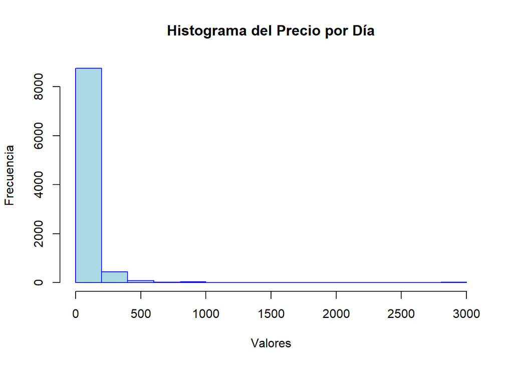

```r
# Histograma del precio por día con gráficos base

hist(df$daily_price,
     ylab = 'Frecuencia',
     xlab = 'Valores',
     main = 'Histograma del Precio por Día',
     col = 'lightblue',
     border = 'blue')
```

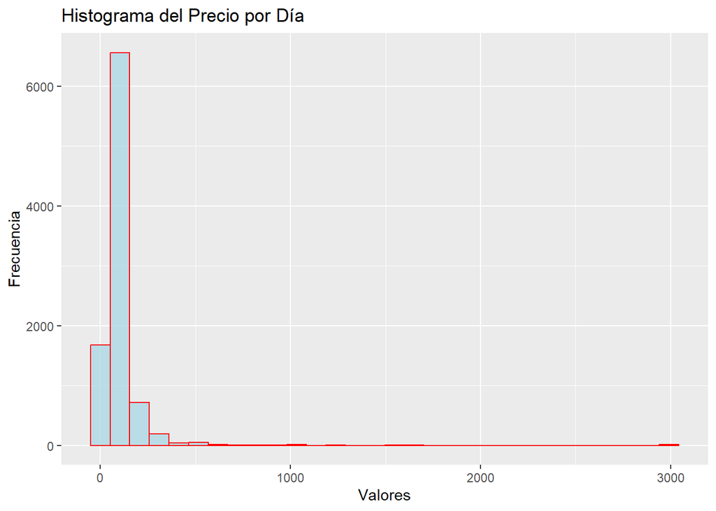

```r
# Histograma del precio por día con ggplot

ggplot(df) +
  geom_histogram(mapping = aes(daily_price), color='red', fill = 'lightblue', alpha = 0.8)+
  ggtitle('Histograma del Precio por Día') +
  xlab("Valores") +
  ylab("Frecuencia")
```

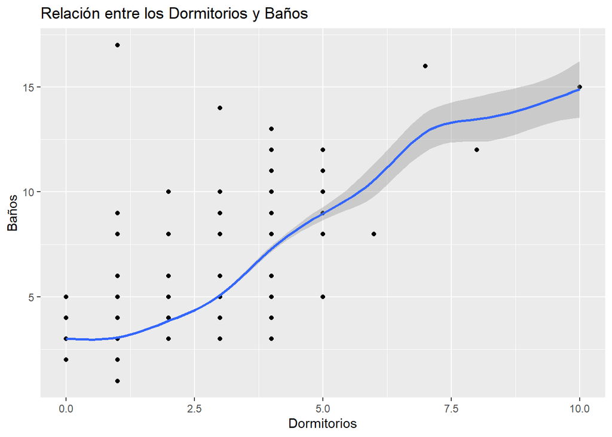

```r
# Relación entre los dormitorios y baños

ggplot(df) +
  geom_point(mapping = aes(bedrooms, bathrooms)) + geom_smooth(aes(bedrooms, bathrooms)) +
  ggtitle("Relación entre los Dormitorios y Baños") +
  xlab("Dormitorios") +
  ylab("Baños")
```

Se visualiza que existe cierta relación esperada, al existir mayor cantidad de dormitorios, es de esperar que existan mayor cantidad de baños.

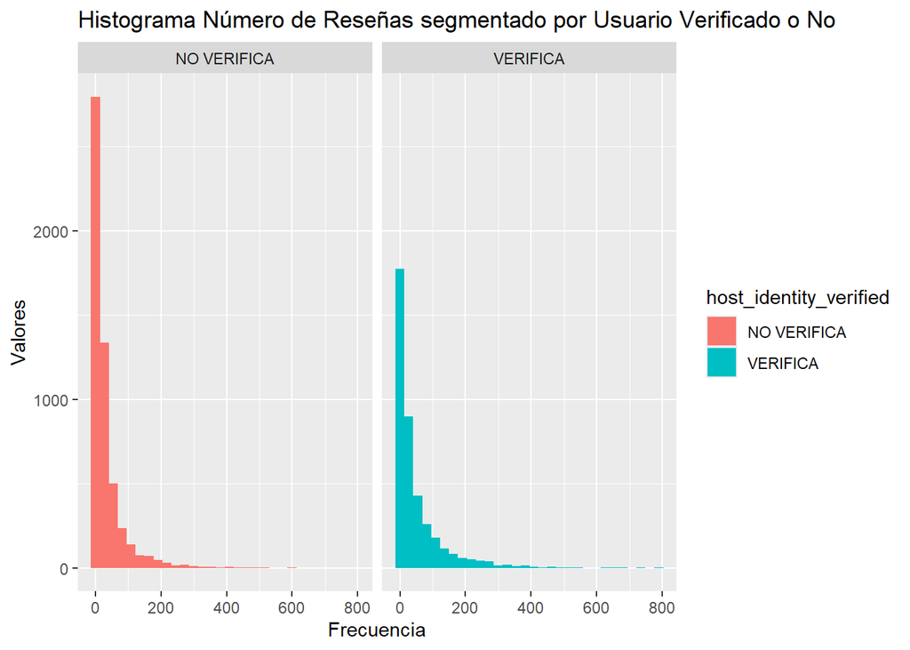

```r
# Histograma del número de reseñas en función de si es un usuario verificado o no

ggplot(df, mapping = aes(number_of_reviews)) +
  geom_histogram(aes(fill=host_identity_verified)) +
  facet_wrap( ~ host_identity_verified) +
  ggtitle("Histograma Número de Reseñas segmentado por Usuario Verificado o No") +
  xlab("Frecuencia") +
  ylab("Valores")
```

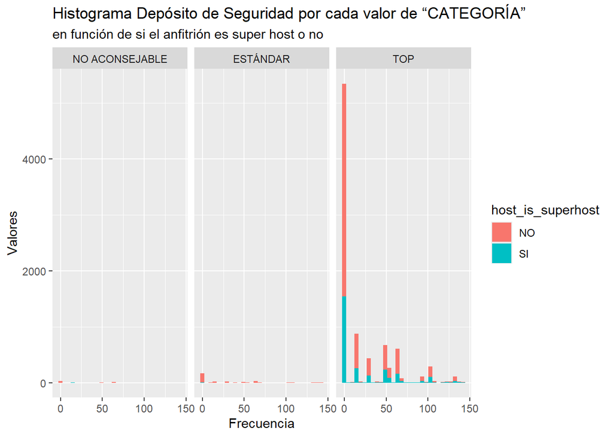

```r
# Mostrar un histograma por cada valor de “CATEGORÍA” en el que se enseñe la cuantía del depósito de seguridad en función de si el anfitrión es super host o no

ggplot(df, mapping = aes(security_deposit)) +
  geom_histogram(aes(fill=host_is_superhost)) +
  facet_wrap( ~ categoria) +
  labs(title = "Histograma Depósito de Seguridad por cada valor de “CATEGORÍA”",
       subtitle = "en función de si el anfitrión es super host o no") +
  xlab("Frecuencia") +
  ylab("Valores")
```